# Sintetik Səhiyyə Məlumatlarının Analizi

Aysu İ

2026-05-11

# 1 Giriş

Bu layihədə **sintetik səhiyyə məlumat dəsti** təhlil edilir. Məlumat dəsti üç əsas cədvəldən ibarətdir:

- **patients** — pasiyentlərin demoqrafik məlumatları
- **encounters** — tibbi müraciətlər
- **observations** — klinik ölçülər (BMI, qan təzyiqi, xolesterin və s.)

Layihənin məqsədi bu üç cədvəli birləşdirərək hərtərəfli deskriptiv təhlil aparmaq, anomaliyaları aşkar etmək, dəyişənlər arasındakı əlaqəni ölçmək və proqnoz modeli qurmaqdan ibarətdir.

# 2 Paketlər və Məlumatın Yüklənməsi

```r
library(data.table)   # Böyük məlumatlarla sürətli iş
library(ggplot2)      # Qrafik vizuallaşdırma
library(dplyr)        # Məlumat manipulyasiyası
library(lubridate)    # Tarix əməliyyatları
library(scales)       # Qrafik ox formatlaması
library(tidyr)        # Məlumat formalarının dəyişdirilməsi
library(knitr)        # Cədvəl formatlaması
library(kableExtra)   # Cədvəl dizaynı
install.packages("kableExtra")
```

```r
patients     <- readRDS("patients.rds")
encounters   <- readRDS("encounters.rds")
observations <- readRDS("observations.rds")

setDT(patients)
setDT(encounters)
setDT(observations)

setnames(patients,     tolower(names(patients)))
setnames(encounters,   tolower(names(encounters)))
setnames(observations, tolower(names(observations)))

cat("Patients sətir sayı:     ", format(nrow(patients),     big.mark=","), "\n")
```

```
## Patients sətir sayı:      132,607
```

```r
cat("Encounters sətir sayı:   ", format(nrow(encounters),   big.mark=","), "\n")
```

```
## Encounters sətir sayı:    1,263,669
```

```r
cat("Observations sətir sayı: ", format(nrow(observations), big.mark=","), "\n")
```

```
## Observations sətir sayı:  5,383,318
```

# 3 Məlumat Strukturu və Hazırlıq

## 3.1 Tarix Sütunlarının Formatlanması

```r
patients[,     birthdate := as.Date(birthdate)]
patients[,     deathdate := as.Date(deathdate)]
encounters[,   date      := as.Date(date)]
observations[, date      := as.Date(date)]
```

## 3.2 Yaş Hesablanması

```r
bugun <- as.Date("2026-05-11")

patients[is.na(deathdate),  yas := as.numeric(bugun - birthdate) / 365.25]
patients[!is.na(deathdate), yas := as.numeric(deathdate - birthdate) / 365.25]

patients <- patients[yas >= 0 & yas <= 120]
```

## 3.3 case_when ilə Yaş Kateqoriyaları

```r
patients[, yas_cat := case_when(
  yas <  18             ~ "Usaq (0-17)",
  yas >= 18 & yas < 35  ~ "Genc (18-34)",
  yas >= 35 & yas < 55  ~ "Orta yas (35-54)",
  yas >= 55 & yas < 70  ~ "Boyuk yas (55-69)",
  yas >= 70             ~ "Yasli (70+)"
)]

patients[, yas_cat := factor(yas_cat, levels = c(
  "Usaq (0-17)", "Genc (18-34)", "Orta yas (35-54)",
  "Boyuk yas (55-69)", "Yasli (70+)"
))]

patients[, .N, by = yas_cat][order(yas_cat)] |>
  kable(col.names = c("Yas Kateqoriyasi", "Pasiyent Sayi"),
        caption = "Yas Kateqoriyalari uzre Pasiyent Sayi") |>
  kable_styling(bootstrap_options = c("striped","hover","condensed"),
                full_width = FALSE)
```

Yas Kateqoriyalari uzre Pasiyent Sayi

| Yas Kateqoriyasi | Pasiyent Sayi |
| --- | --- |
| Usaq (0-17) | 12468 |
| Genc (18-34) | 25044 |
| Orta yas (35-54) | 34730 |
| Boyuk yas (55-69) | 31830 |
| Yasli (70+) | 28535 |

# 4 Deskriptiv Tehlil

## 4.1 Pasiyentler (Patients)

### 4.1.1 Umumi Statistika

```r
yas_stat <- patients[, .(
  `Orta Yas`   = round(mean(yas, na.rm=TRUE), 1),
  `Median Yas` = round(median(yas, na.rm=TRUE), 1),
  `Std Sapma`  = round(sd(yas, na.rm=TRUE), 1),
  `Min Yas`    = round(min(yas, na.rm=TRUE), 1),
  `Max Yas`    = round(max(yas, na.rm=TRUE), 1)
)]

kable(yas_stat, caption = "Pasiyent Yasinin Deskriptiv Statistikasi") |>
  kable_styling(bootstrap_options = c("striped","hover"), full_width = FALSE)
```

Pasiyent Yasinin Deskriptiv Statistikasi

| Orta Yas | Median Yas | Std Sapma | Min Yas | Max Yas |
| --- | --- | --- | --- | --- |
| 50.3 | 51.9 | 22.3 | 0 | 108.4 |

### 4.1.2 Cins Paylanmasi

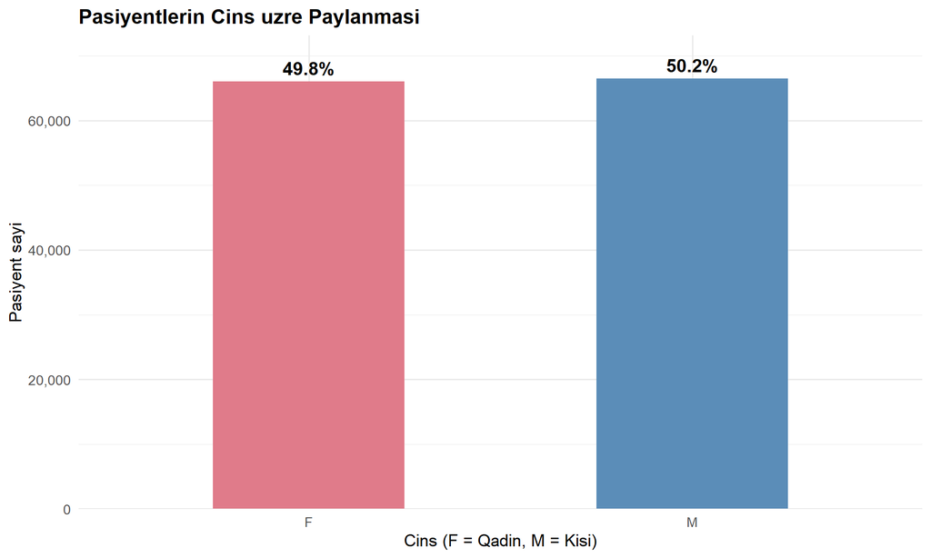

```r
cins <- patients[, .N, by = gender]
cins[, faiz := round(N / sum(N) * 100, 1)]
cins[, label := paste0(faiz, "%")]

ggplot(cins, aes(x = gender, y = N, fill = gender)) +
  geom_col(width = 0.5, show.legend = FALSE) +
  geom_text(aes(label = label), vjust = -0.5, size = 5, fontface = "bold") +
  scale_fill_manual(values = c("F" = "#e07b8a", "M" = "#5b8db8")) +
  scale_y_continuous(labels = comma, expand = expansion(mult = c(0, 0.1))) +
  labs(title = "Pasiyentlerin Cins uzre Paylanmasi",
       x = "Cins (F = Qadin, M = Kisi)", y = "Pasiyent sayi") +
  theme_minimal(base_size = 13) +
  theme(plot.title = element_text(face = "bold"))
```

> **Serh:** Melumat dəstindeki pasiyentler cins baximindan texminen beraber paylanmisdir. Bu sintetik datanin balanslasdirılmis yaradildigini gosterir.

### 4.1.3 Yas Paylanmasi (Cins uzre)

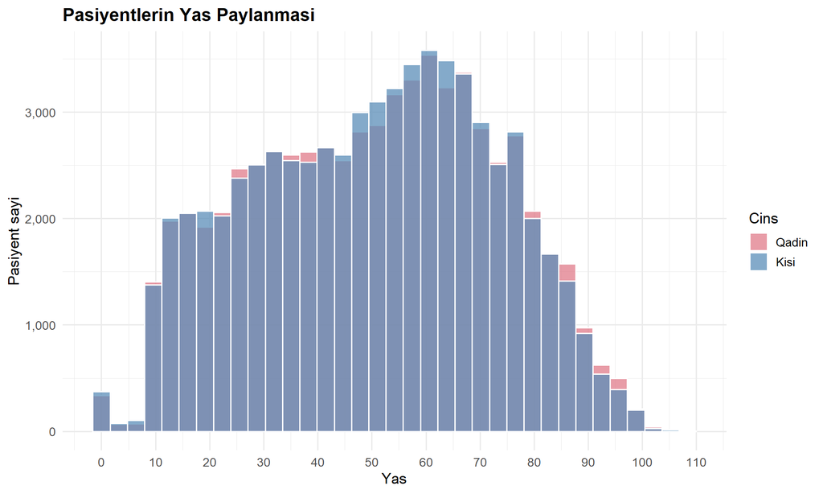

```r
ggplot(patients, aes(x = yas, fill = gender)) +
  geom_histogram(bins = 35, alpha = 0.75, position = "identity", color = "white") +
  scale_fill_manual(values = c("F" = "#e07b8a", "M" = "#5b8db8"),
                    name = "Cins", labels = c("Qadin", "Kisi")) +
  scale_x_continuous(breaks = seq(0, 120, 10)) +
  scale_y_continuous(labels = comma) +
  labs(title = "Pasiyentlerin Yas Paylanmasi",
       x = "Yas", y = "Pasiyent sayi") +
  theme_minimal(base_size = 13) +
  theme(plot.title = element_text(face = "bold"))
```

> **Serh:** Yas paylanmasi genis diapazonu ehatə edir. Her iki cinsdə orta yas qrupunun daha cox temsil olundugu musahide edilir.

### 4.1.4 Yas Kateqoriyalari uzre Boxplot

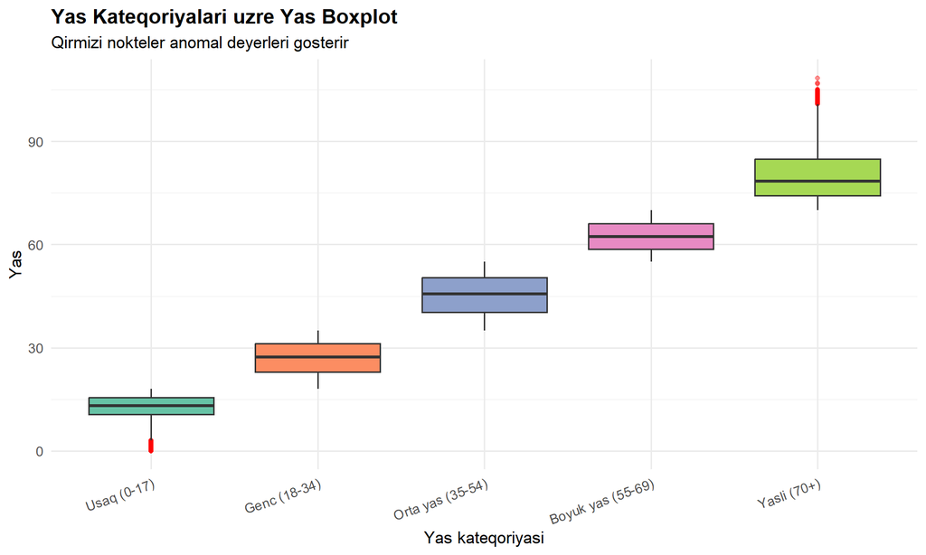

```r
ggplot(patients, aes(x = yas_cat, y = yas, fill = yas_cat)) +
  geom_boxplot(show.legend = FALSE, outlier.color = "red",
               outlier.alpha = 0.4, outlier.size = 1.5) +
  scale_fill_brewer(palette = "Set2") +
  labs(title    = "Yas Kateqoriyalari uzre Yas Boxplot",
       subtitle = "Qirmizi nokteler anomal deyerleri gosterir",
       x = "Yas kateqoriyasi", y = "Yas") +
  theme_minimal(base_size = 13) +
  theme(plot.title = element_text(face = "bold"),
        axis.text.x = element_text(angle = 20, hjust = 1))
```

> **Serh:** Boxplot her yas qrupunun daxili paylanmasini gosterir. Qirmizi nokteler IQR metoduna gore anomal sayilan deyerlerdir.

### 4.1.5 Irq Paylanmasi

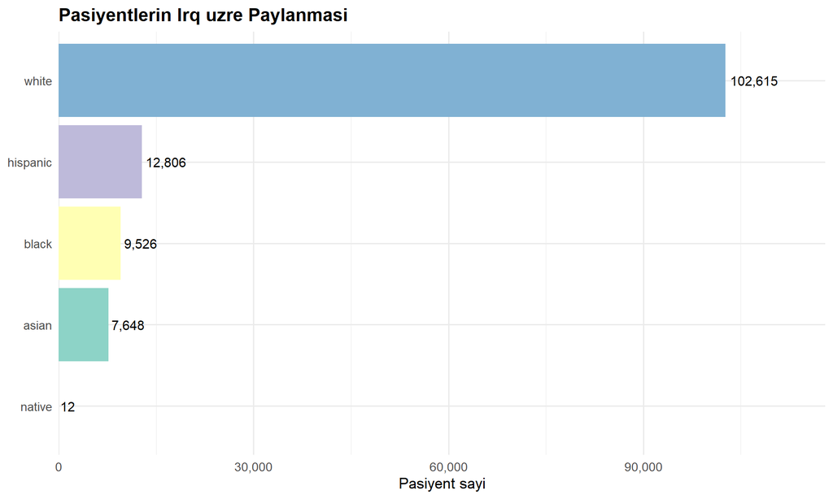

```r
irq <- patients[, .N, by = race][order(-N)]

ggplot(irq, aes(x = reorder(race, N), y = N, fill = race)) +
  geom_col(show.legend = FALSE) +
  geom_text(aes(label = comma(N)), hjust = -0.1, size = 4) +
  coord_flip() +
  scale_y_continuous(labels = comma, expand = expansion(mult = c(0, 0.15))) +
  scale_fill_brewer(palette = "Set3") +
  labs(title = "Pasiyentlerin Irq uzre Paylanmasi",
       x = NULL, y = "Pasiyent sayi") +
  theme_minimal(base_size = 13) +
  theme(plot.title = element_text(face = "bold"))
```

> **Serh:** Melumat dəstindeki irq paylanmasi muxtelif etnik qruplari ehatə edir. En cox temsil olunan qrup aydin sekilde ferqlenir.

### 4.1.6 Olum Statistikasi

```r
olum_stat <- patients[, .(
  `Sag olan`        = sum(is.na(deathdate)),
  `Vefat etmis`     = sum(!is.na(deathdate)),
  `Umumi`           = .N,
  `Olum faizi (%)` = round(sum(!is.na(deathdate)) / .N * 100, 1)
)]

kable(olum_stat, caption = "Pasiyentlerin Heyat Statusu") |>
  kable_styling(bootstrap_options = c("striped","hover"), full_width = FALSE)
```

Pasiyentlerin Heyat Statusu

| Sag olan | Vefat etmis | Umumi | Olum faizi (%) |
| --- | --- | --- | --- |
| 99533 | 33074 | 132607 | 24.9 |

## 4.2 Muracietler (Encounters)

### 4.2.1 Iller uzre Muraciet Trendi

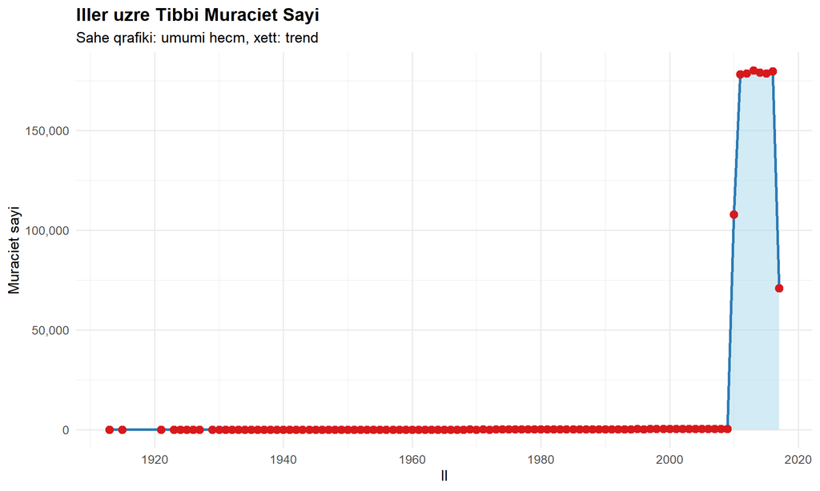

```r
encounters[, il := year(date)]
il_say <- encounters[, .N, by = il][order(il)]

ggplot(il_say, aes(x = il, y = N)) +
  geom_area(fill = "#a8d8ea", alpha = 0.5) +
  geom_line(color = "#2c7bb6", linewidth = 1.2) +
  geom_point(color = "#d7191c", size = 3) +
  scale_y_continuous(labels = comma) +
  scale_x_continuous(breaks = scales::pretty_breaks(n = 8)) +
  labs(title    = "Iller uzre Tibbi Muraciet Sayi",
       subtitle = "Sahe qrafiki: umumi hecm, xett: trend",
       x = "Il", y = "Muraciet sayi") +
  theme_minimal(base_size = 13) +
  theme(plot.title = element_text(face = "bold"))
```

### 4.2.2 En Cox Rast Gelingen Muraciet Sebebleri (Top 10)

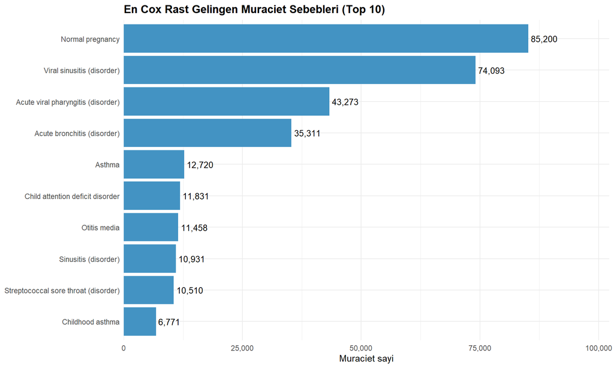

```r
sebeb <- encounters[
  !is.na(reasondescription) & reasondescription != "",
  .N, by = reasondescription
][order(-N)][1:10]

ggplot(sebeb, aes(x = reorder(reasondescription, N), y = N)) +
  geom_col(fill = "#4393c3") +
  geom_text(aes(label = comma(N)), hjust = -0.1, size = 3.5) +
  coord_flip() +
  scale_y_continuous(labels = comma, expand = expansion(mult = c(0, 0.2))) +
  labs(title = "En Cox Rast Gelingen Muraciet Sebebleri (Top 10)",
       x = NULL, y = "Muraciet sayi") +
  theme_minimal(base_size = 11) +
  theme(plot.title = element_text(face = "bold"))
```

### 4.2.3 Pasiyent basina Muraciet Sayinin Aqreqasiyasi

```r
enc_per_pat <- encounters[, .N, by = patient]

enc_stat <- enc_per_pat[, .(
  `Orta muraciet`   = round(mean(N), 1),
  `Median muraciet` = round(median(N), 1),
  `Std Sapma`       = round(sd(N), 1),
  `Minimum`         = min(N),
  `Maksimum`        = max(N)
)]

kable(enc_stat, caption = "Pasiyent basina Muraciet Sayinin Statistikasi") |>
  kable_styling(bootstrap_options = c("striped","hover"), full_width = FALSE)
```

Pasiyent basina Muraciet Sayinin Statistikasi

| Orta muraciet | Median muraciet | Std Sapma | Minimum | Maksimum |
| --- | --- | --- | --- | --- |
| 10.7 | 9 | 9.6 | 1 | 122 |

## 4.3 Musahideler (Observations)

### 4.3.1 BMI Melumatinin Hazirlanmasi ve case_when

```r
bmi_data <- observations[description %like% "Body Mass Index" |
                          description %like% "BMI"]
bmi_data[, value := as.numeric(value)]
bmi_data <- bmi_data[!is.na(value) & value > 10 & value < 80]

bmi_data[, bmi_cat := case_when(
  value < 18.5                ~ "Zeif ceki",
  value >= 18.5 & value < 25  ~ "Normal",
  value >= 25   & value < 30  ~ "Artiq ceki",
  value >= 30                 ~ "Obez"
)]

bmi_data[, bmi_cat := factor(bmi_cat,
  levels = c("Zeif ceki", "Normal", "Artiq ceki", "Obez"))]

bmi_data[, .N, by = bmi_cat][order(bmi_cat)] |>
  kable(col.names = c("BMI Kateqoriyasi", "Olcu Sayi"),
        caption = "BMI Kateqoriyalari uzre Paylanma") |>
  kable_styling(bootstrap_options = c("striped","hover"), full_width = FALSE)
```

BMI Kateqoriyalari uzre Paylanma

| BMI Kateqoriyasi | Olcu Sayi |
| --- | --- |
| Zeif ceki | 97841 |
| Normal | 94548 |
| Artiq ceki | 67868 |
| Obez | 257956 |

### 4.3.2 BMI Paylanmasi

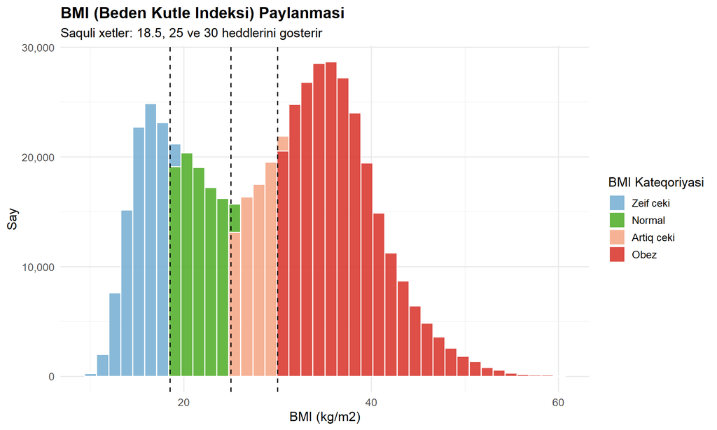

```r
bmi_renk <- c("Zeif ceki"  = "#74add1",
               "Normal"     = "#4dac26",
               "Artiq ceki" = "#f4a582",
               "Obez"       = "#d73027")

ggplot(bmi_data, aes(x = value, fill = bmi_cat)) +
  geom_histogram(bins = 40, color = "white", alpha = 0.85) +
  geom_vline(xintercept = c(18.5, 25, 30),
             linetype = "dashed", color = "black", linewidth = 0.7) +
  scale_fill_manual(values = bmi_renk, name = "BMI Kateqoriyasi") +
  scale_y_continuous(labels = comma) +
  labs(title    = "BMI (Beden Kutle Indeksi) Paylanmasi",
       subtitle = "Saquli xetler: 18.5, 25 ve 30 heddlerini gosterir",
       x = "BMI (kg/m2)", y = "Say") +
  theme_minimal(base_size = 13) +
  theme(plot.title = element_text(face = "bold"))
```

> **Serh:** BMI paylanmasi saga meyllidir — artiq cekili ve obez pasiyentlerin sayi nezerecarpackderecede yuksekdir. Bu muasir cemiyyetde piylenme problemine isare edir.

### 4.3.3 Qan Tezyiqi (Sistol) Paylanmasi

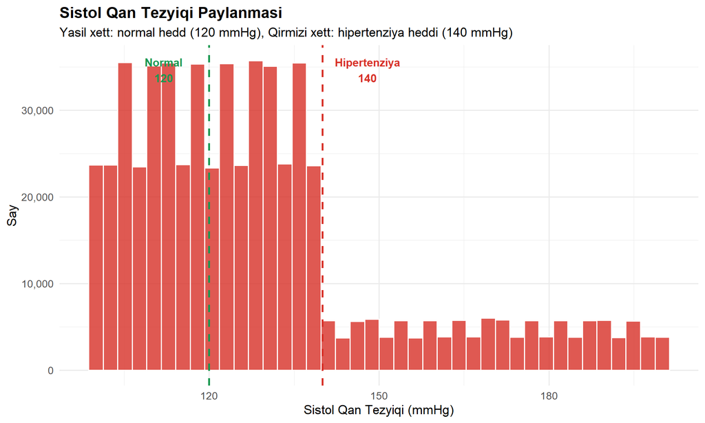

```r
bp_data <- observations[description %like% "Systolic Blood Pressure" |
                         description %like% "systolic"]
bp_data[, value := as.numeric(value)]
bp_data <- bp_data[!is.na(value) & value > 50 & value < 250]

ggplot(bp_data, aes(x = value)) +
  geom_histogram(bins = 40, fill = "#d73027", color = "white", alpha = 0.8) +
  geom_vline(xintercept = 120, linetype = "dashed",
             color = "#1a9850", linewidth = 1) +
  geom_vline(xintercept = 140, linetype = "dashed",
             color = "#d73027", linewidth = 1) +
  annotate("text", x = 112, y = Inf, label = "Normal\n120",
           vjust = 1.5, color = "#1a9850", size = 4, fontface = "bold") +
  annotate("text", x = 148, y = Inf, label = "Hipertenziya\n140",
           vjust = 1.5, color = "#d73027", size = 4, fontface = "bold") +
  scale_y_continuous(labels = comma) +
  labs(title    = "Sistol Qan Tezyiqi Paylanmasi",
       subtitle = "Yasil xett: normal hedd (120 mmHg), Qirmizi xett: hipertenziya heddi (140 mmHg)",
       x = "Sistol Qan Tezyiqi (mmHg)", y = "Say") +
  theme_minimal(base_size = 13) +
  theme(plot.title = element_text(face = "bold"))
```

> **Serh:** Qan tezyiqi paylanmasinda pasiyentlerin boyuk hissesinin 120 mmHg-den yuxari deyerlere malik oldugu gorunur. Bu hipertenziya riskinin yuksek oldugunu gosterir.

### 4.3.4 BMI Kateqoriyalari uzre Boxplot

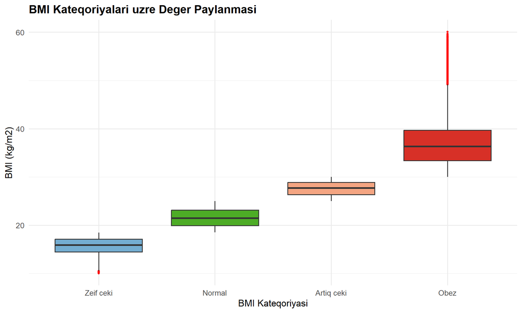

```r
ggplot(bmi_data, aes(x = bmi_cat, y = value, fill = bmi_cat)) +
  geom_boxplot(show.legend = FALSE, outlier.color = "red",
               outlier.alpha = 0.3, outlier.size = 1) +
  scale_fill_manual(values = bmi_renk) +
  labs(title = "BMI Kateqoriyalari uzre Deger Paylanmasi",
       x = "BMI Kateqoriyasi", y = "BMI (kg/m2)") +
  theme_minimal(base_size = 13) +
  theme(plot.title = element_text(face = "bold"))
```

> **Serh:** Her kateqoriyanin daxili paylanmasi boxplot vasitesile aydin gorunur. Obez qrupunda daha genis yayilma musahide olunur.

# 5 Cedvellerin Birlesdirmesi (JOIN)

```r
enc_pat <- merge(
  encounters,
  patients[, .(id, yas, yas_cat, gender, race, marital)],
  by.x = "patient",
  by.y = "id",
  all.x = TRUE
)

bmi_pat <- merge(
  bmi_data[, .(patient, date, value, bmi_cat)],
  patients[, .(id, yas, yas_cat, gender, race)],
  by.x = "patient",
  by.y = "id",
  all.x = TRUE
)

cat("Birlesdirmis enc_pat setir sayi: ", format(nrow(enc_pat), big.mark=","), "\n")
```

```
## Birlesdirmis enc_pat setir sayi:  1,263,669
```

```r
cat("Birlesdirmis bmi_pat setir sayi: ", format(nrow(bmi_pat), big.mark=","), "\n")
```

```
## Birlesdirmis bmi_pat setir sayi:  518,213
```

## 5.1 Yas Kateqoriyasi uzre Muraciet Sayi

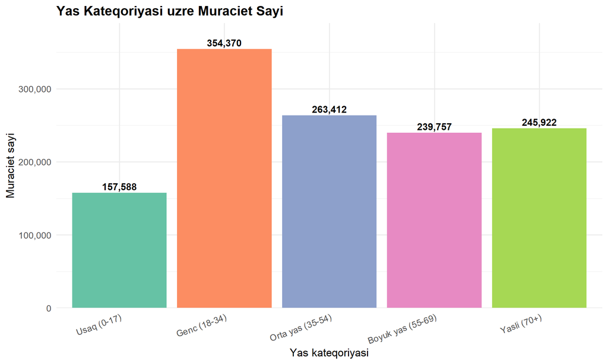

```r
yas_enc <- enc_pat[!is.na(yas_cat), .N, by = yas_cat][order(yas_cat)]

ggplot(yas_enc, aes(x = yas_cat, y = N, fill = yas_cat)) +
  geom_col(show.legend = FALSE) +
  geom_text(aes(label = comma(N)), vjust = -0.4, size = 4, fontface = "bold") +
  scale_fill_brewer(palette = "Set2") +
  scale_y_continuous(labels = comma, expand = expansion(mult = c(0, 0.1))) +
  labs(title = "Yas Kateqoriyasi uzre Muraciet Sayi",
       x = "Yas kateqoriyasi", y = "Muraciet sayi") +
  theme_minimal(base_size = 13) +
  theme(plot.title = element_text(face = "bold"),
        axis.text.x = element_text(angle = 20, hjust = 1))
```

## 5.2 Cins ve Yas Kateqoriyasina gore Muraciet (Facet)

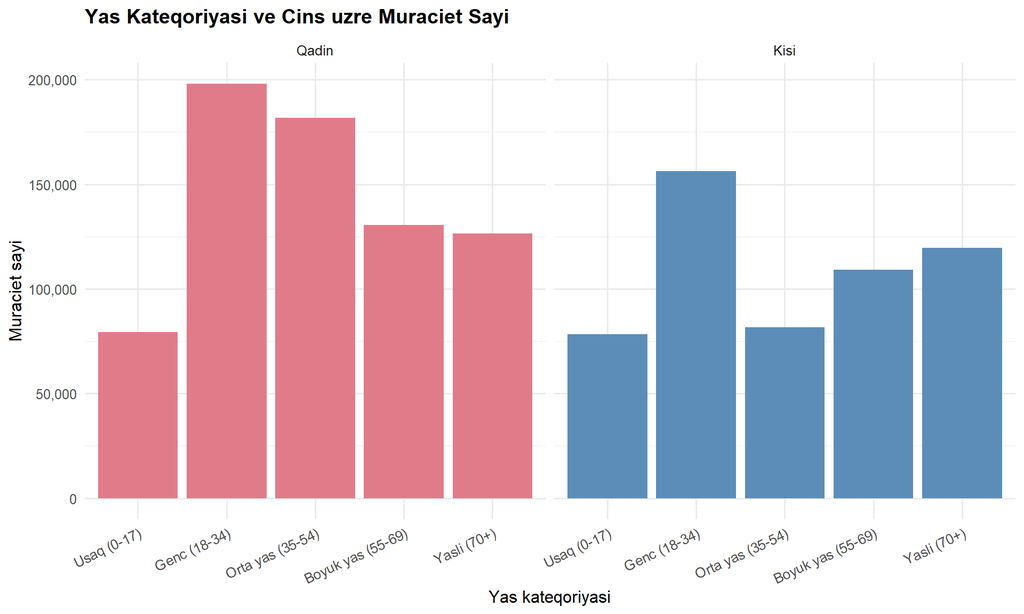

```r
yas_cins <- enc_pat[!is.na(yas_cat) & !is.na(gender),
                    .N, by = .(yas_cat, gender)]

ggplot(yas_cins, aes(x = yas_cat, y = N, fill = gender)) +
  geom_col(position = "dodge") +
  scale_fill_manual(values = c("F" = "#e07b8a", "M" = "#5b8db8"),
                    name = "Cins", labels = c("Qadin","Kisi")) +
  scale_y_continuous(labels = comma) +
  facet_wrap(~ gender, labeller = labeller(gender = c("F"="Qadin","M"="Kisi"))) +
  labs(title = "Yas Kateqoriyasi ve Cins uzre Muraciet Sayi",
       x = "Yas kateqoriyasi", y = "Muraciet sayi") +
  theme_minimal(base_size = 12) +
  theme(plot.title  = element_text(face = "bold"),
        axis.text.x = element_text(angle = 25, hjust = 1),
        legend.position = "none")
```

## 5.3 BMI Kateqoriyasi uzre Yas Paylanmasi (Facet)

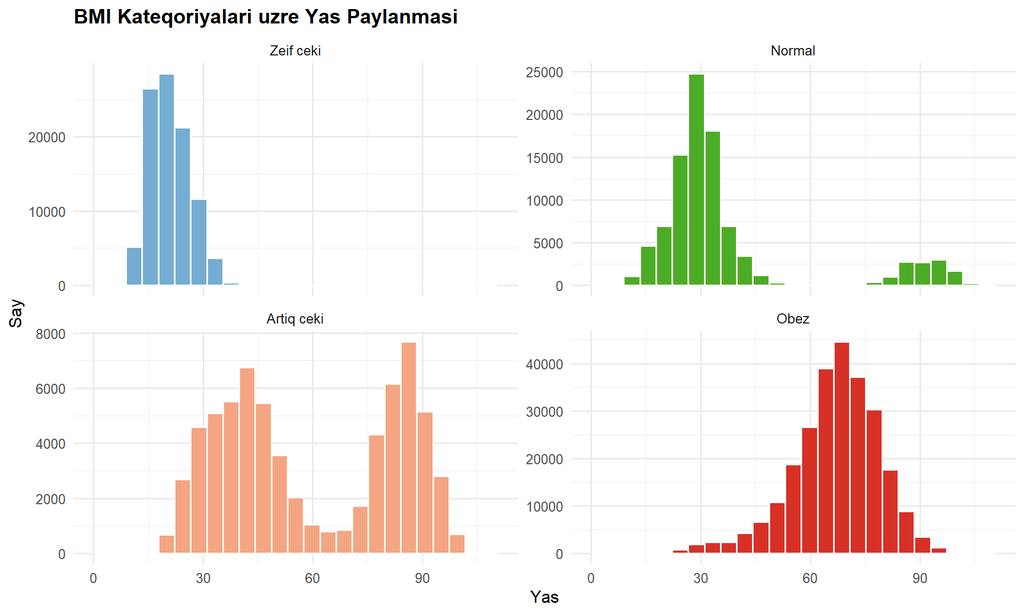

```r
ggplot(bmi_pat[!is.na(yas) & !is.na(bmi_cat)],
       aes(x = yas, fill = bmi_cat)) +
  geom_histogram(bins = 25, color = "white", show.legend = FALSE) +
  scale_fill_manual(values = bmi_renk) +
  facet_wrap(~ bmi_cat, scales = "free_y") +
  labs(title = "BMI Kateqoriyalari uzre Yas Paylanmasi",
       x = "Yas", y = "Say") +
  theme_minimal(base_size = 12) +
  theme(plot.title = element_text(face = "bold"))
```

# 6 Anomaliyalar

## 6.1 IQR Metodu ile BMI Anomaliyalari

```r
Q1_bmi  <- quantile(bmi_data$value, 0.25, na.rm = TRUE)
Q3_bmi  <- quantile(bmi_data$value, 0.75, na.rm = TRUE)
IQR_bmi <- Q3_bmi - Q1_bmi
alt_bmi <- Q1_bmi - 1.5 * IQR_bmi
ust_bmi <- Q3_bmi + 1.5 * IQR_bmi

bmi_data[, anomaliya := value < alt_bmi | value > ust_bmi]

anom_stat <- data.table(
  Gostərici = c("Q1", "Q3", "IQR", "Alt hedd", "Ust hedd", "Anomaliya sayi"),
  Deger     = c(round(Q1_bmi,2), round(Q3_bmi,2), round(IQR_bmi,2),
                round(alt_bmi,2), round(ust_bmi,2),
                bmi_data[anomaliya == TRUE, .N])
)

kable(anom_stat, caption = "BMI Anomaliya Analizi (IQR Metodu)") |>
  kable_styling(bootstrap_options = c("striped","hover"), full_width = FALSE)
```

BMI Anomaliya Analizi (IQR Metodu)

| Gostərici | Deger |
| --- | --- |
| Q1 | 20.44 |
| Q3 | 36.28 |
| IQR | 15.84 |
| Alt hedd | -3.32 |
| Ust hedd | 60.04 |
| Anomaliya sayi | 5.00 |

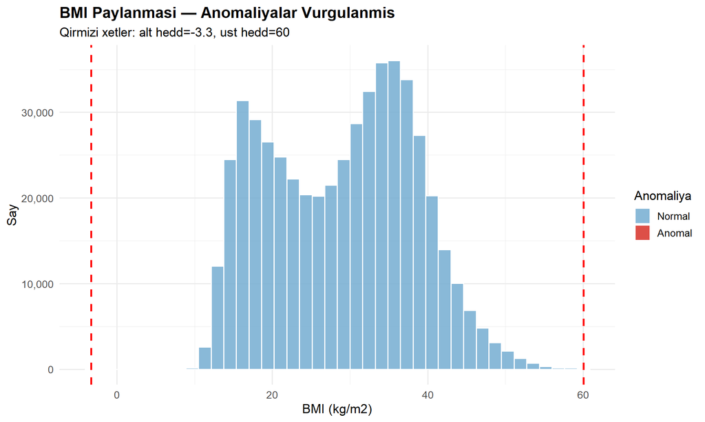

```r
ggplot(bmi_data, aes(x = value, fill = anomaliya)) +
  geom_histogram(bins = 40, color = "white", alpha = 0.85) +
  geom_vline(xintercept = c(alt_bmi, ust_bmi),
             linetype = "dashed", color = "red", linewidth = 1) +
  scale_fill_manual(values = c("FALSE" = "#74add1", "TRUE" = "#d73027"),
                    name = "Anomaliya", labels = c("Normal", "Anomal")) +
  scale_y_continuous(labels = comma) +
  labs(title    = "BMI Paylanmasi — Anomaliyalar Vurgulanmis",
       subtitle = paste0("Qirmizi xetler: alt hedd=", round(alt_bmi,1),
                         ", ust hedd=", round(ust_bmi,1)),
       x = "BMI (kg/m2)", y = "Say") +
  theme_minimal(base_size = 13) +
  theme(plot.title = element_text(face = "bold"))
```

> **Serh:** IQR metoduna gore BMI deyerlerinin kicik bir hissesi anomal sayilir. Bu deyerler olcum xetasi, xususi tibbi veziyyet ve ya nadir hal ola biler.

## 6.2 Pasiyent basina Muraciet Sayinda Anomaliyalar

```r
Q1_e  <- quantile(enc_per_pat$N, 0.25)
Q3_e  <- quantile(enc_per_pat$N, 0.75)
IQR_e <- Q3_e - Q1_e
ust_e <- Q3_e + 1.5 * IQR_e

enc_per_pat[, anomaliya := N > ust_e]

cat("Anomal muraciet heddi: >", round(ust_e, 0), "\n")
```

```
## Anomal muraciet heddi: > 25
```

```r
cat("Anomal pasiyent sayi:", enc_per_pat[anomaliya == TRUE, .N], "\n")
```

```
## Anomal pasiyent sayi: 6137
```

```r
cat("Maksimum muraciet sayi:", max(enc_per_pat$N), "\n")
```

```
## Maksimum muraciet sayi: 122
```

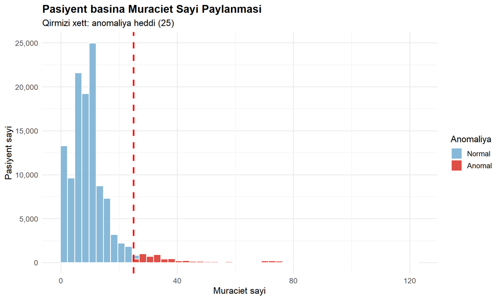

```r
ggplot(enc_per_pat, aes(x = N, fill = anomaliya)) +
  geom_histogram(bins = 50, color = "white", alpha = 0.85) +
  geom_vline(xintercept = ust_e, color = "red",
             linetype = "dashed", linewidth = 1.2) +
  scale_fill_manual(values = c("FALSE" = "#74add1", "TRUE" = "#d73027"),
                    name = "Anomaliya", labels = c("Normal", "Anomal")) +
  scale_y_continuous(labels = comma) +
  labs(title    = "Pasiyent basina Muraciet Sayi Paylanmasi",
       subtitle = paste0("Qirmizi xett: anomaliya heddi (", round(ust_e,0), ")"),
       x = "Muraciet sayi", y = "Pasiyent sayi") +
  theme_minimal(base_size = 13) +
  theme(plot.title = element_text(face = "bold"))
```

> **Serh:** Pasiyentlerin boyuk eksseriyyeti normal muraciet sayina sahib olsa da, kicik bir qrup statistik anomaliya teskil edir. Bu pasiyentler xroniki ve ya agir xesteliyin gostericisi ola biler.

# 7 Korrelyasiya Analizi

## 7.1 Yas ve BMI Arasindaki Korrelyasiya

```r
bmi_yas <- merge(
  bmi_data[, .(patient, value, bmi_cat)],
  patients[, .(id, yas, yas_cat, gender)],
  by.x = "patient",
  by.y = "id",
  all.x = TRUE
)
bmi_yas <- bmi_yas[!is.na(yas) & !is.na(value)]

kor_r <- cor(bmi_yas$yas, bmi_yas$value, use = "complete.obs")

cat("Pearson korrelyasiya emsali (r):", round(kor_r, 4), "\n")
```

```
## Pearson korrelyasiya emsali (r): 0.7092
```

```r
cat("Serh:", ifelse(abs(kor_r) < 0.2, "Cox zeif elaqe",
               ifelse(abs(kor_r) < 0.4, "Zeif elaqe",
                 ifelse(abs(kor_r) < 0.6, "Orta elaqe", "Guclu elaqe"))), "\n")
```

```
## Serh: Guclu elaqe
```

## 7.2 Scatter Plot + Reqressiya Xetti

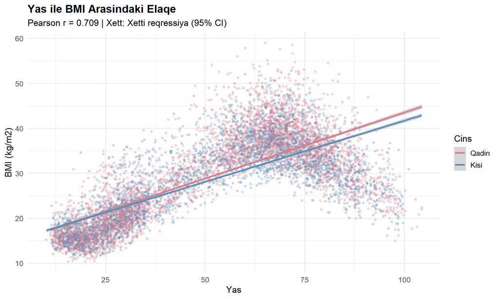

```r
set.seed(42)
numune <- bmi_yas[sample(.N, min(8000, .N))]

ggplot(numune, aes(x = yas, y = value, color = gender)) +
  geom_point(alpha = 0.25, size = 1.2) +
  geom_smooth(method = "lm", se = TRUE, linewidth = 1.2) +
  scale_color_manual(values = c("F" = "#e07b8a", "M" = "#5b8db8"),
                     name = "Cins", labels = c("Qadin","Kisi")) +
  labs(title    = "Yas ile BMI Arasindaki Elaqe",
       subtitle = paste0("Pearson r = ", round(kor_r, 3),
                         " | Xett: Xetti reqressiya (95% CI)"),
       x = "Yas", y = "BMI (kg/m2)") +
  theme_minimal(base_size = 13) +
  theme(plot.title = element_text(face = "bold"))
```

# 8 Reqressiya Analizi

## 8.1 Sade Xetti Reqressiya (BMI ~ Yas)

```r
model_sade <- lm(value ~ yas, data = bmi_yas)
summary(model_sade)
```

```
##
## Call:
## lm(formula = value ~ yas, data = bmi_yas)
##
## Residuals:
##      Min       1Q   Median       3Q      Max
## -31.1959  -4.0698  -0.3646   4.1713  28.8802
##
## Coefficients:
##              Estimate Std. Error t value Pr(>|t|)
## (Intercept) 1.460e+01  2.189e-02   667.1   <2e-16 ***
## yas         2.771e-01  3.831e-04   723.3   <2e-16 ***
## ---
## Signif. codes:  0 '***' 0.001 '**' 0.01 '*' 0.05 '.' 0.1 ' ' 1
##
## Residual standard error: 6.641 on 517138 degrees of freedom
## Multiple R-squared:  0.5029, Adjusted R-squared:  0.5029
## F-statistic: 5.232e+05 on 1 and 517138 DF,  p-value: < 2.2e-16
```

```r
reg_stat <- data.table(
  Gostərici = c("R2 (Determinasiya emsali)",
                "Duzeldilmis R2",
                "Kesisme noktesi (intercept)",
                "Yasin emsali (coefficient)",
                "p-deger (yas)"),
  Deger = c(
    round(summary(model_sade)$r.squared, 4),
    round(summary(model_sade)$adj.r.squared, 4),
    round(coef(model_sade)[1], 4),
    round(coef(model_sade)[2], 4),
    format(summary(model_sade)$coefficients[2,4], scientific=TRUE, digits=3)
  )
)

kable(reg_stat, caption = "Sade Xetti Reqressiya Neticeleri (BMI ~ Yas)") |>
  kable_styling(bootstrap_options = c("striped","hover"), full_width = FALSE)
```

Sade Xetti Reqressiya Neticeleri (BMI ~ Yas)

| Gostərici | Deger |
| --- | --- |
| R2 (Determinasiya emsali) | 0.5029 |
| Duzeldilmis R2 | 0.5029 |
| Kesisme noktesi (intercept) | 14.6008 |
| Yasin emsali (coefficient) | 0.2771 |
| p-deger (yas) | 0e+00 |

## 8.2 Murekkeb Xetti Reqressiya (BMI ~ Yas + Cins)

```r
bmi_yas[, gender_n := ifelse(gender == "F", 1, 0)]
model_cox <- lm(value ~ yas + gender_n, data = bmi_yas)
summary(model_cox)
```

```
##
## Call:
## lm(formula = value ~ yas + gender_n, data = bmi_yas)
##
## Residuals:
##      Min       1Q   Median       3Q      Max
## -31.5454  -4.0649  -0.3413   4.1804  28.5268
##
## Coefficients:
##              Estimate Std. Error t value Pr(>|t|)
## (Intercept) 1.424e+01  2.375e-02  599.48   <2e-16 ***
## yas         2.771e-01  3.826e-04  724.20   <2e-16 ***
## gender_n    7.201e-01  1.845e-02   39.04   <2e-16 ***
## ---
## Signif. codes:  0 '***' 0.001 '**' 0.01 '*' 0.05 '.' 0.1 ' ' 1
##
## Residual standard error: 6.632 on 517137 degrees of freedom
## Multiple R-squared:  0.5044, Adjusted R-squared:  0.5044
## F-statistic: 2.631e+05 on 2 and 517137 DF,  p-value: < 2.2e-16
```

```r
reg_cox <- data.table(
  Gostərici = c("R2 (Determinasiya emsali)",
                "Duzeldilmis R2",
                "Kesisme noktesi",
                "Yasin emsali",
                "Cinsin emsali"),
  Deger = c(
    round(summary(model_cox)$r.squared, 4),
    round(summary(model_cox)$adj.r.squared, 4),
    round(coef(model_cox)[1], 4),
    round(coef(model_cox)[2], 4),
    round(coef(model_cox)[3], 4)
  )
)

kable(reg_cox, caption = "Murekkeb Xetti Reqressiya Neticeleri (BMI ~ Yas + Cins)") |>
  kable_styling(bootstrap_options = c("striped","hover"), full_width = FALSE)
```

Murekkeb Xetti Reqressiya Neticeleri (BMI ~ Yas + Cins)

| Gostərici | Deger |
| --- | --- |
| R2 (Determinasiya emsali) | 0.5044 |
| Duzeldilmis R2 | 0.5044 |
| Kesisme noktesi | 14.2378 |
| Yasin emsali | 0.2771 |
| Cinsin emsali | 0.7201 |

> **Serh:** Murekkeb reqressiya modelinə cins deyiseni elave edildikde modelin izahetme gucu artir. Bu, cinsin BMI uzerindeki mustequil tesirini gosterir.

# 9 Proqnoz ve Ferziyyeler

## 9.1 Ferziyye 1 — Yasli Pasiyentlerde Muraciet Yuku Artir

```r
enc_yas <- merge(
  enc_per_pat[, .(patient, enc_n = N)],
  patients[, .(id, yas_cat)],
  by.x = "patient",
  by.y = "id"
)

yas_enc_stat <- enc_yas[!is.na(yas_cat), .(
  `Orta muraciet`   = round(mean(enc_n), 1),
  `Median muraciet` = round(median(enc_n), 1),
  `Pasiyent sayi`   = .N
), by = yas_cat][order(yas_cat)]

kable(yas_enc_stat,
      caption = "Yas Kateqoriyasi uzre Muraciet Statistikasi") |>
  kable_styling(bootstrap_options = c("striped","hover"), full_width = FALSE)
```

Yas Kateqoriyasi uzre Muraciet Statistikasi

| yas_cat | Orta muraciet | Median muraciet | Pasiyent sayi |
| --- | --- | --- | --- |
| Usaq (0-17) | 14.2 | 15 | 11087 |
| Genc (18-34) | 14.9 | 10 | 23793 |
| Orta yas (35-54) | 8.3 | 5 | 31663 |
| Boyuk yas (55-69) | 8.6 | 8 | 27809 |
| Yasli (70+) | 10.3 | 10 | 23987 |

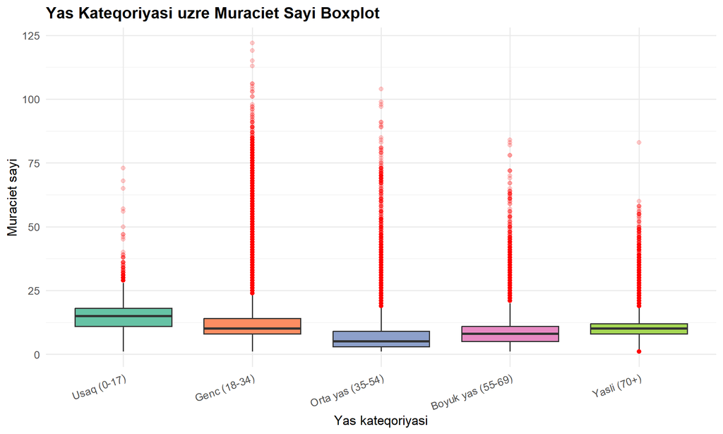

```r
ggplot(enc_yas[!is.na(yas_cat)], aes(x = yas_cat, y = enc_n, fill = yas_cat)) +
  geom_boxplot(show.legend = FALSE,
               outlier.alpha = 0.2, outlier.color = "red") +
  scale_fill_brewer(palette = "Set2") +
  scale_y_continuous(labels = comma) +
  labs(title = "Yas Kateqoriyasi uzre Muraciet Sayi Boxplot",
       x = "Yas kateqoriyasi", y = "Muraciet sayi") +
  theme_minimal(base_size = 13) +
  theme(plot.title  = element_text(face = "bold"),
        axis.text.x = element_text(angle = 20, hjust = 1))
```

## 9.2 Ferziyye 2 — Obez Pasiyentler Daha Tez-Tez Muraciet Edir

```r
bmi_enc <- merge(
  bmi_data[, .(patient, bmi_cat)],
  enc_per_pat[, .(patient, enc_n = N)],
  by = "patient"
)
bmi_enc <- unique(bmi_enc, by = "patient")

bmi_enc_stat <- bmi_enc[, .(
  `Orta muraciet` = round(mean(enc_n), 1),
  `Pasiyent sayi` = .N
), by = bmi_cat][order(bmi_cat)]

kable(bmi_enc_stat,
      caption = "BMI Kateqoriyasi uzre Orta Muraciet Sayi") |>
  kable_styling(bootstrap_options = c("striped","hover"), full_width = FALSE)
```

BMI Kateqoriyasi uzre Orta Muraciet Sayi

| bmi_cat | Orta muraciet | Pasiyent sayi |
| --- | --- | --- |
| Zeif ceki | 15.9 | 19218 |
| Normal | 13.2 | 18400 |
| Artiq ceki | 10.1 | 16270 |
| Obez | 10.2 | 50817 |

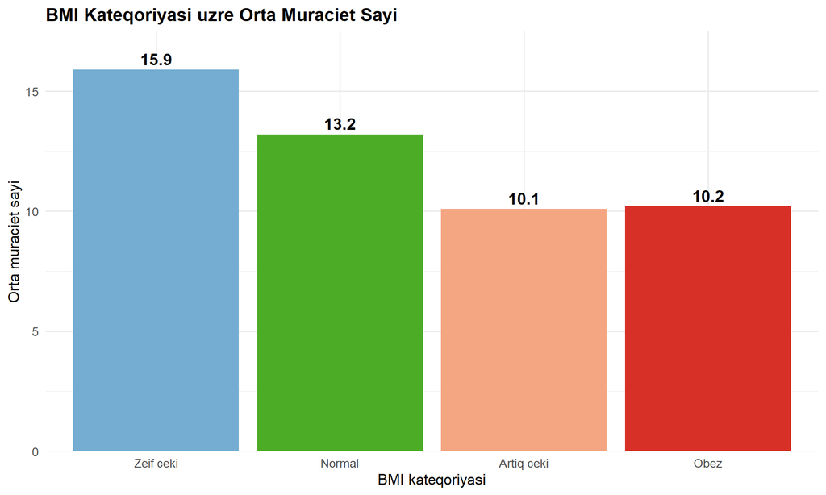

```r
ggplot(bmi_enc_stat, aes(x = bmi_cat, y = `Orta muraciet`, fill = bmi_cat)) +
  geom_col(show.legend = FALSE) +
  geom_text(aes(label = `Orta muraciet`), vjust = -0.4,
            size = 5, fontface = "bold") +
  scale_fill_manual(values = bmi_renk) +
  scale_y_continuous(expand = expansion(mult = c(0, 0.1))) +
  labs(title = "BMI Kateqoriyasi uzre Orta Muraciet Sayi",
       x = "BMI kateqoriyasi", y = "Orta muraciet sayi") +
  theme_minimal(base_size = 13) +
  theme(plot.title = element_text(face = "bold"))
```